# UCR

## Escuela de Matemática

### Herramientas de Ciencias de Datos I (CA-0204)

### Examen II

**Profesor**: Luis Juárez Potoy

**Estudiante**:  
Anthonny Flores Rojas (C32975)

**Fecha**: 30 de noviembre de 2025

# 1

```r
# Librerias
library(tidyverse)
library(readr)

# Data frame con los datos
df <- read.csv("C:/Users/antho/Documents/UCR/Semestre_I_2025/CA0204/Examen2/CA0204-Examen_II_C32975/data/moras.txt", stringsAsFactors = FALSE)


# Correcion de error
df <- df %>%
  rename(INDICADOR_EXTRANJERO = INDICADOR.EXTRANJERO)


head(df)
```

```
  IDENTIFICACION   SEXO   SALARIO               TIPO_ASEGURAMIENTO
1              1 HOMBRE                                 ASALARIADO
2              2 HOMBRE   3315014 PENSIONADOS EN SU PROPIO SISTEMA
3              3  MUJER 270486,01                       ASALARIADO
4              4  MUJER 544949,83                       ASALARIADO
5              5  MUJER    210000                       ASALARIADO
6              6 HOMBRE    397150                       ASALARIADO
          SECTOR INDICADOR_ACTIVO INDICADOR_EXTRANJERO INDICADOR_MOROSO EDAD
1 SECTOR PUBLICO               SI                   NO               NO   42
2 SECTOR PUBLICO               SI                   NO               NO   77
3 SECTOR PRIVADO               SI                   NO               NO   45
4 SECTOR PRIVADO               SI                   NO               NO   49
5 SECTOR PRIVADO               SI                   NO               NO   42
6 SECTOR PRIVADO               SI                   NO               NO   44
```

# 2

```r
# Variables numericas
numeric <- c("IDENTIFICACION","SALARIO","EDAD")

# Correcion de tipo
df$SALARIO <- as.numeric(gsub(",", ".", df$SALARIO))


# Resumen
summary <- df %>%
  summarise(
    IDENTIFICACION_promedio = mean(IDENTIFICACION, na.rm = TRUE),
    IDENTIFICACION_mediana  = median(IDENTIFICACION, na.rm = TRUE),
    IDENTIFICACION_sd       = sd(IDENTIFICACION, na.rm = TRUE),
    IDENTIFICACION_min      = min(IDENTIFICACION, na.rm = TRUE),
    IDENTIFICACION_max      = max(IDENTIFICACION, na.rm = TRUE),

    SALARIO_promedio = mean(SALARIO, na.rm = TRUE),
    SALARIO_mediana  = median(SALARIO, na.rm = TRUE),
    SALARIO_sd       = sd(SALARIO, na.rm = TRUE),
    SALARIO_min      = min(SALARIO, na.rm = TRUE),
    SALARIO_max      = max(SALARIO, na.rm = TRUE),

    EDAD_promedio = mean(EDAD, na.rm = TRUE),
    EDAD_mediana  = median(EDAD, na.rm = TRUE),
    EDAD_sd       = sd(EDAD, na.rm = TRUE),
    EDAD_min      = min(EDAD, na.rm = TRUE),
    EDAD_max      = max(EDAD, na.rm = TRUE)
  )

print(summary)
```

```
  IDENTIFICACION_promedio IDENTIFICACION_mediana IDENTIFICACION_sd
1                  2500.5                 2500.5           1443.52
  IDENTIFICACION_min IDENTIFICACION_max SALARIO_promedio SALARIO_mediana
1                  1               5000         657534.3          408495
  SALARIO_sd SALARIO_min SALARIO_max EDAD_promedio EDAD_mediana  EDAD_sd
1   811002.4          10    16858742      41.90634           40 14.16926
  EDAD_min EDAD_max
1       14       99
```

# 3

```r
# Meter los valores atipicos
df <- df %>%
  mutate(
    VALOR_ATIPICO_SALARIO = ifelse(!is.na(SALARIO) & abs((SALARIO - mean(SALARIO, na.rm=TRUE))/sd(SALARIO, na.rm=TRUE)) > 1.96, "SI", "NO"),
    VALOR_ATIPICO_EDAD    = ifelse(!is.na(EDAD)    & abs((EDAD    - mean(EDAD,    na.rm=TRUE))/sd(EDAD,    na.rm=TRUE)) > 1.96, "SI", "NO")
  )

head(df)
```

```
  IDENTIFICACION   SEXO   SALARIO               TIPO_ASEGURAMIENTO
1              1 HOMBRE        NA                       ASALARIADO
2              2 HOMBRE 3315014.0 PENSIONADOS EN SU PROPIO SISTEMA
3              3  MUJER  270486.0                       ASALARIADO
4              4  MUJER  544949.8                       ASALARIADO
5              5  MUJER  210000.0                       ASALARIADO
6              6 HOMBRE  397150.0                       ASALARIADO
          SECTOR INDICADOR_ACTIVO INDICADOR_EXTRANJERO INDICADOR_MOROSO EDAD
1 SECTOR PUBLICO               SI                   NO               NO   42
2 SECTOR PUBLICO               SI                   NO               NO   77
3 SECTOR PRIVADO               SI                   NO               NO   45
4 SECTOR PRIVADO               SI                   NO               NO   49
5 SECTOR PRIVADO               SI                   NO               NO   42
6 SECTOR PRIVADO               SI                   NO               NO   44
  VALOR_ATIPICO_SALARIO VALOR_ATIPICO_EDAD
1                    NO                 NO
2                    SI                 SI
3                    NO                 NO
4                    NO                 NO
5                    NO                 NO
6                    NO                 NO
```

# 4

```r
# Porcentajes de NA
na.percentange <- colMeans(is.na(df)) * 100

print(na.percentange)
```

```
       IDENTIFICACION                  SEXO               SALARIO
                 0.00                  0.00                  0.06
   TIPO_ASEGURAMIENTO                SECTOR      INDICADOR_ACTIVO
                 0.00                  0.00                  0.00
 INDICADOR_EXTRANJERO      INDICADOR_MOROSO                  EDAD
                 0.00                  0.00                  0.06
VALOR_ATIPICO_SALARIO    VALOR_ATIPICO_EDAD
                 0.00                  0.00
```

# 5

```r
# Cambiar NA por mediana igual a excel
df <- df %>%
  mutate(
    SALARIO = ifelse(is.na(SALARIO), median(SALARIO, na.rm = TRUE), SALARIO),
    EDAD    = ifelse(is.na(EDAD),    median(EDAD,    na.rm = TRUE), EDAD)
  )

na.percentange <- colMeans(is.na(df)) * 100

print(na.percentange)
```

```
       IDENTIFICACION                  SEXO               SALARIO
                    0                     0                     0
   TIPO_ASEGURAMIENTO                SECTOR      INDICADOR_ACTIVO
                    0                     0                     0
 INDICADOR_EXTRANJERO      INDICADOR_MOROSO                  EDAD
                    0                     0                     0
VALOR_ATIPICO_SALARIO    VALOR_ATIPICO_EDAD
                    0                     0
```

# 6

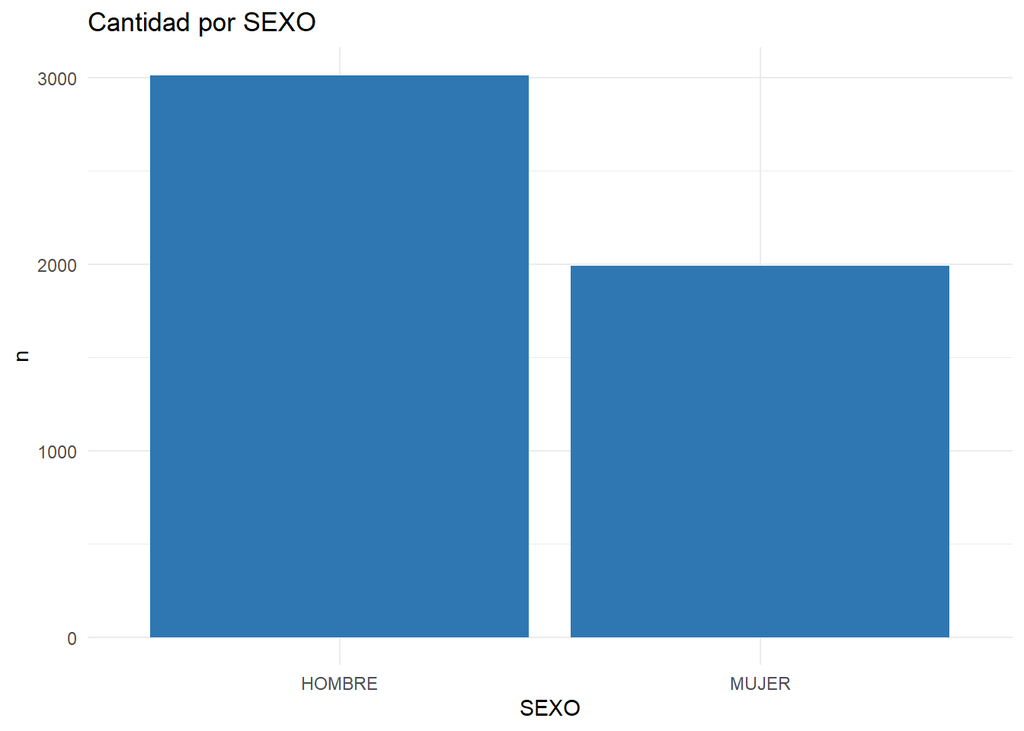

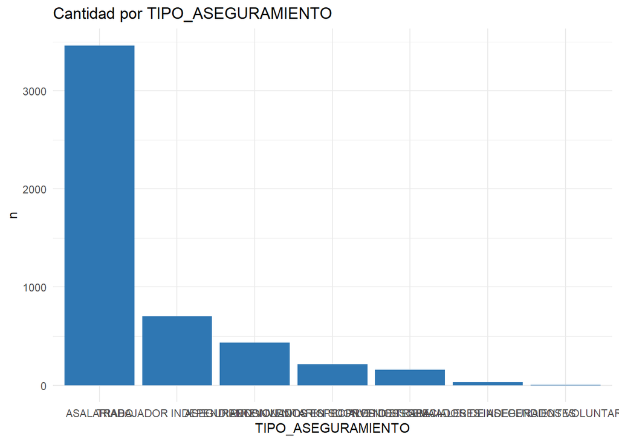

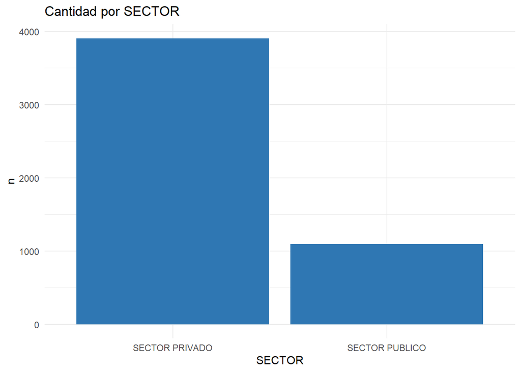

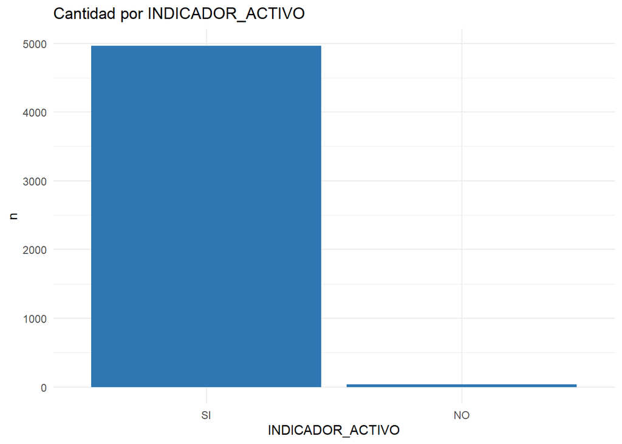

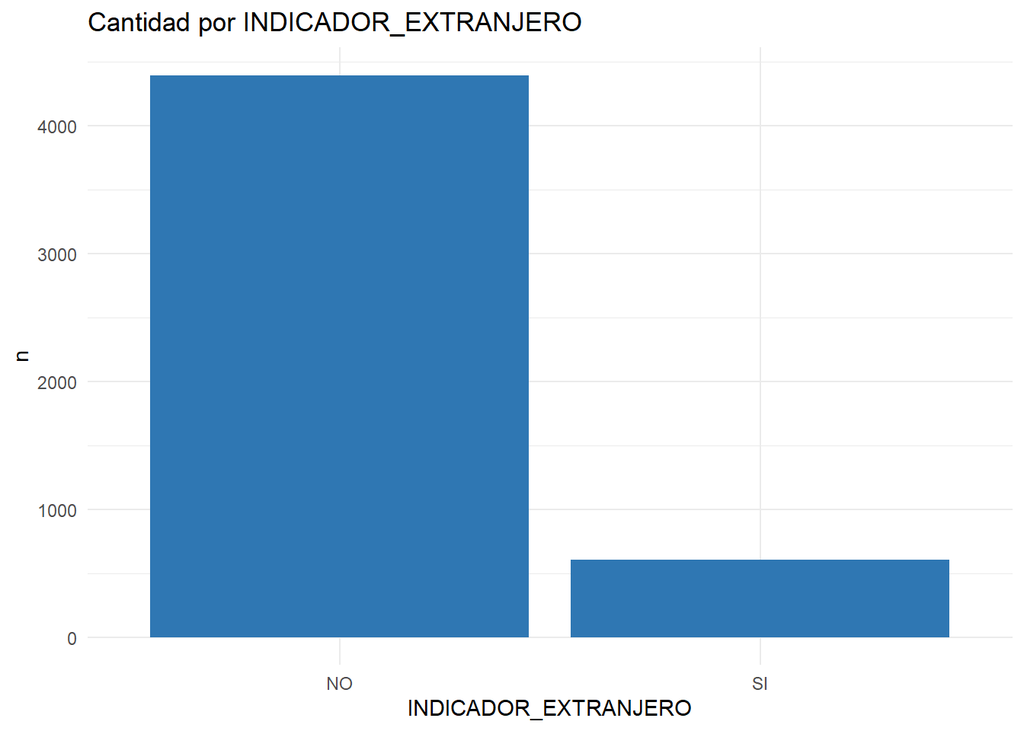

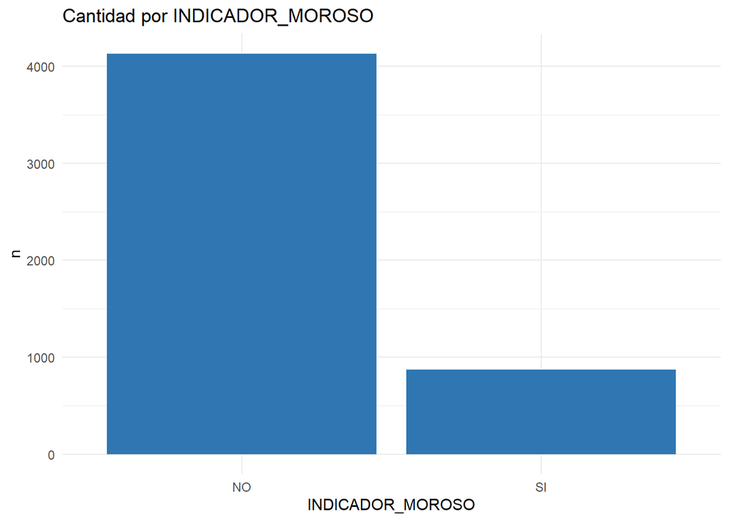

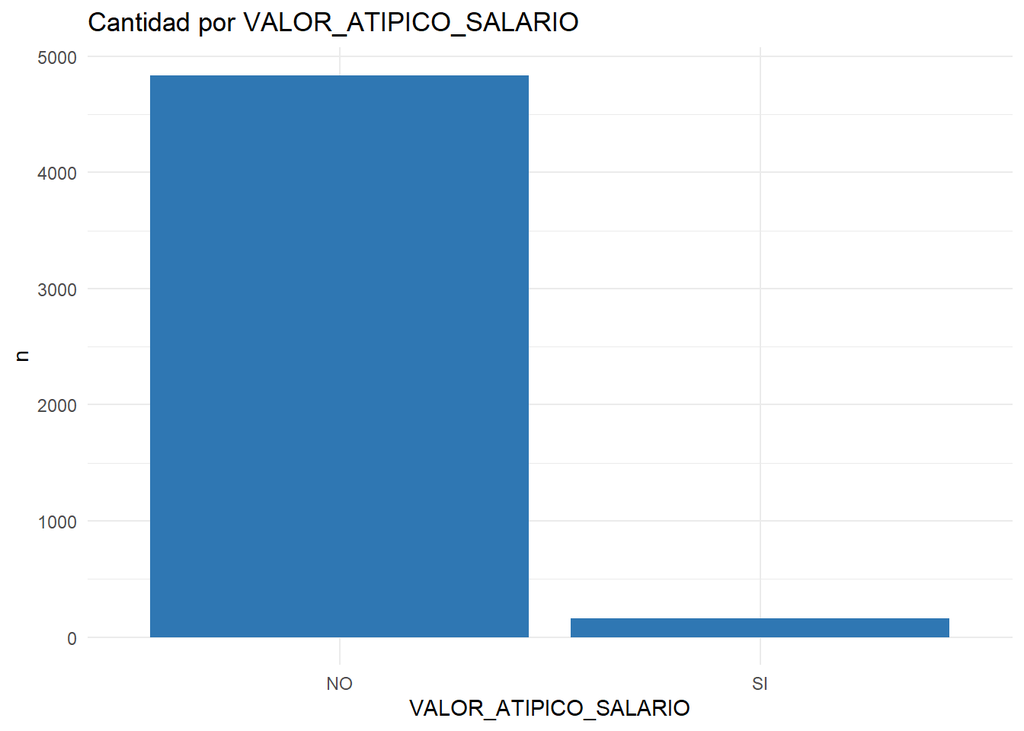

```r
library(ggplot2)
library(forcats)

# Definir columnas
cot <- c("SEXO","TIPO_ASEGURAMIENTO","SECTOR", "INDICADOR_ACTIVO","INDICADOR_EXTRANJERO", "INDICADOR_MOROSO","VALOR_ATIPICO_SALARIO")

cat <- c("SALARIO","EDAD")

# Todas las demas
for (var in cot) {
  print(
    ggplot(df, aes(x = fct_infreq(.data[[var]]))) +
      geom_bar(fill = "#2F77B3") +
      labs(title = paste("Cantidad por", var), x = var, y = "n") +
      theme_minimal()
  )
}
```

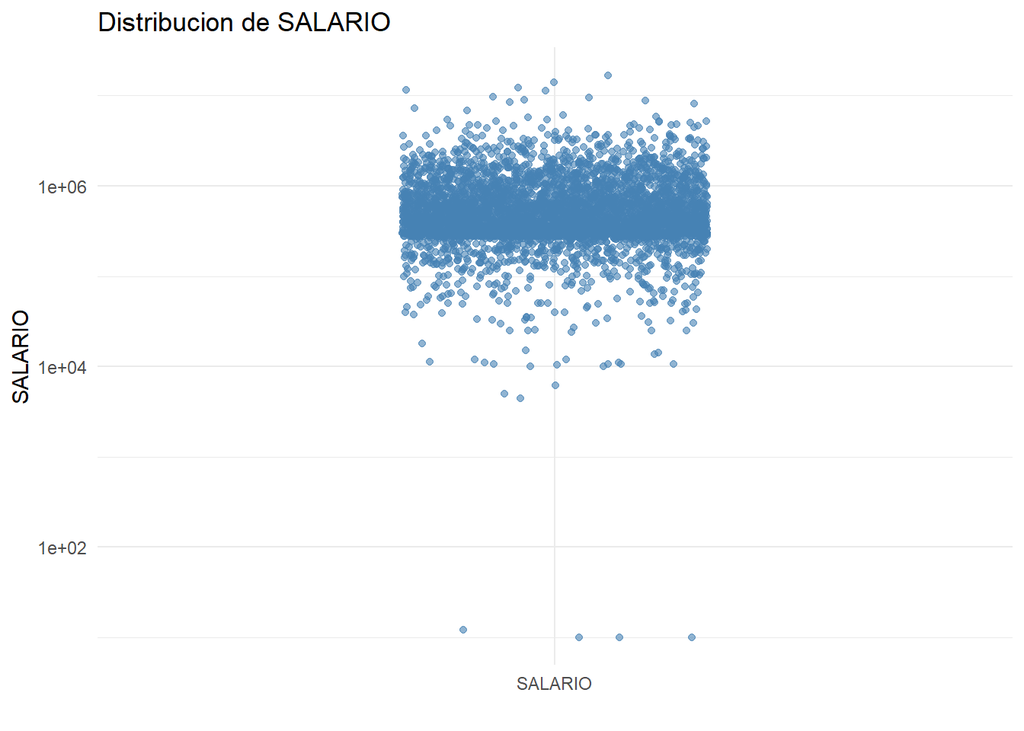

```r
# Salario y edad
ggplot(df, aes(x = "SALARIO", y = SALARIO)) +
  geom_jitter(width = 0.2, color = "steelblue", alpha = 0.6) +
  scale_y_log10() +
  labs(title = "Distribucion de SALARIO",
       x = "", y = "SALARIO") +
  theme_minimal()
```

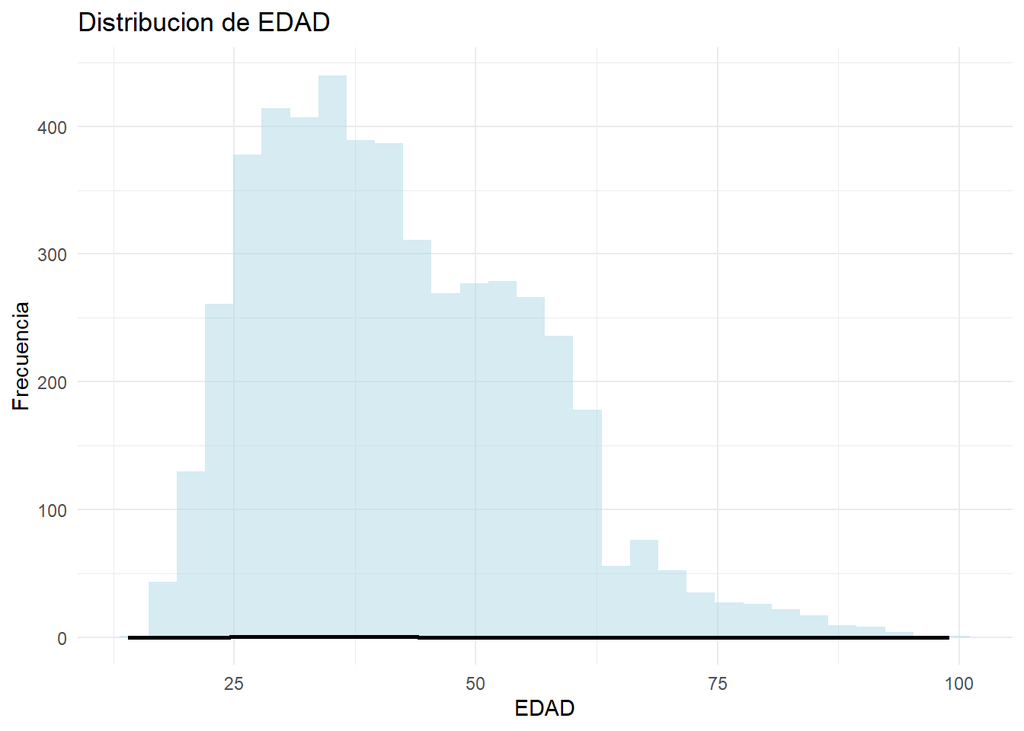

```r
ggplot(df, aes(x = EDAD)) +
  geom_histogram(fill = "lightblue", bins = 30, alpha = 0.5) +
  geom_density(color = "black", size = 1) +
  labs(title = "Distribucion de EDAD", x = "EDAD", y = "Frecuencia") +
  theme_minimal()
```

# 7 y 8

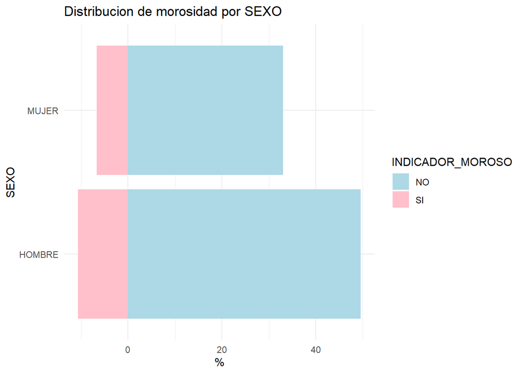

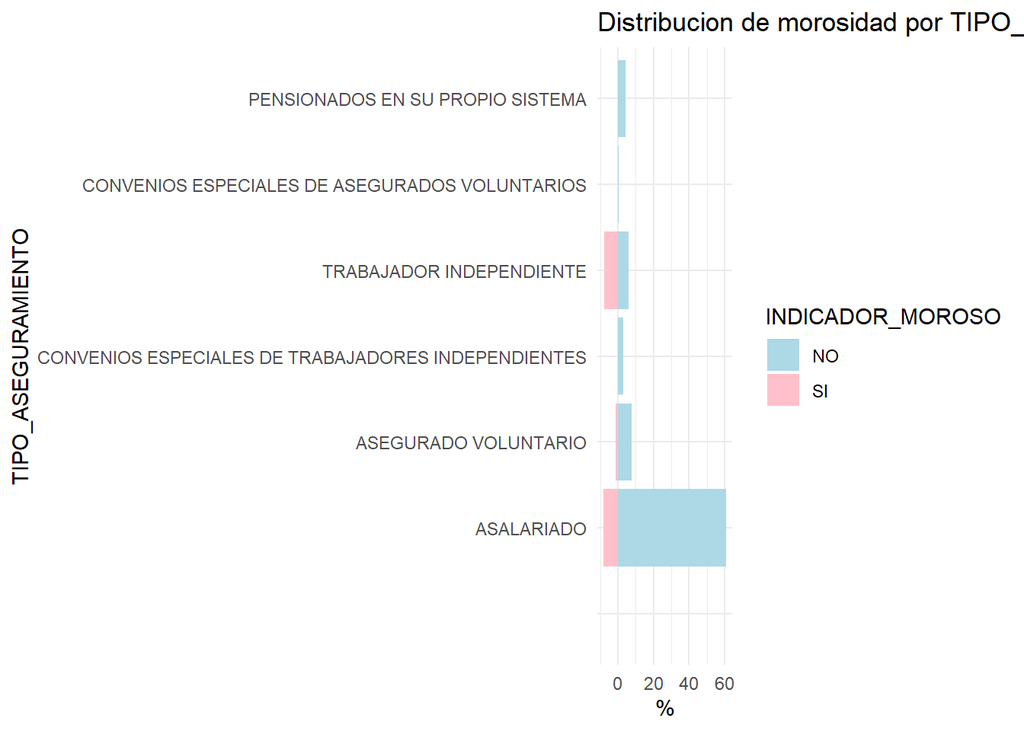

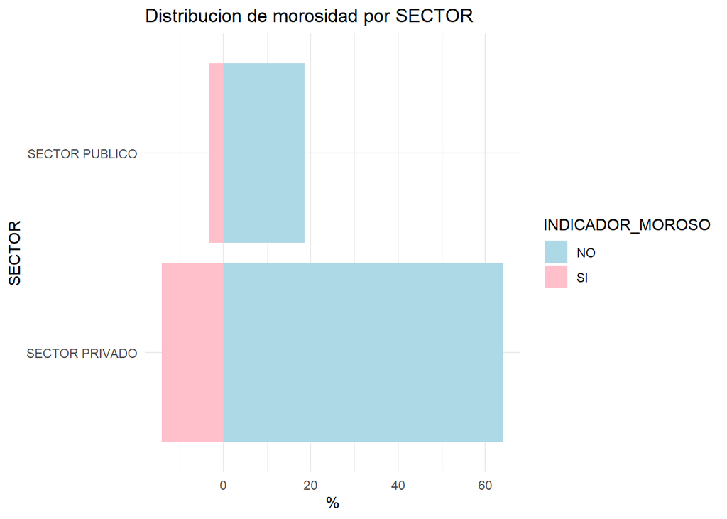

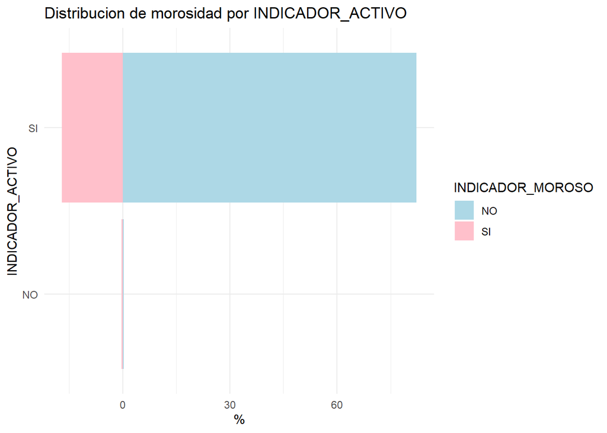

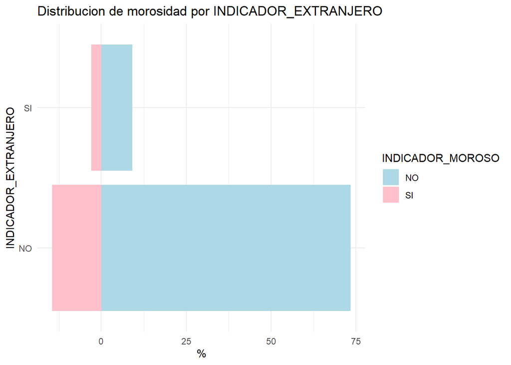

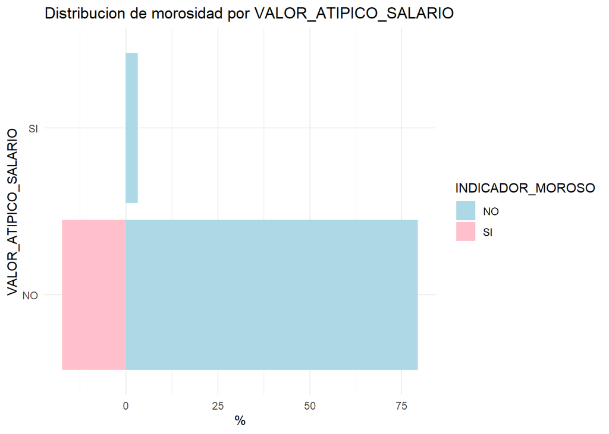

```r
# Definir columnas
cot <- c("SEXO","TIPO_ASEGURAMIENTO","SECTOR",
         "INDICADOR_ACTIVO","INDICADOR_EXTRANJERO",
         "VALOR_ATIPICO_SALARIO")

cat <- c("SALARIO","EDAD")


for (var in cot) {
  plot <- df %>%
    group_by(.data[[var]], INDICADOR_MOROSO) %>%
    summarise(n = n(), .groups = "drop") %>%
    mutate(pct = n / sum(n) * 100,
           lado = ifelse(INDICADOR_MOROSO == "SI", -pct, pct)) %>%
    ggplot(aes(x = fct_infreq(.data[[var]]), y = lado, fill = INDICADOR_MOROSO)) +
      geom_col() +
      coord_flip() +
      scale_fill_manual(values = c("SI" = "pink", "NO" = "lightblue")) +
      labs(title = paste("Distribucion de morosidad por", var),
           x = var, y = "%") +
      theme_minimal()

  print(plot)
}
```

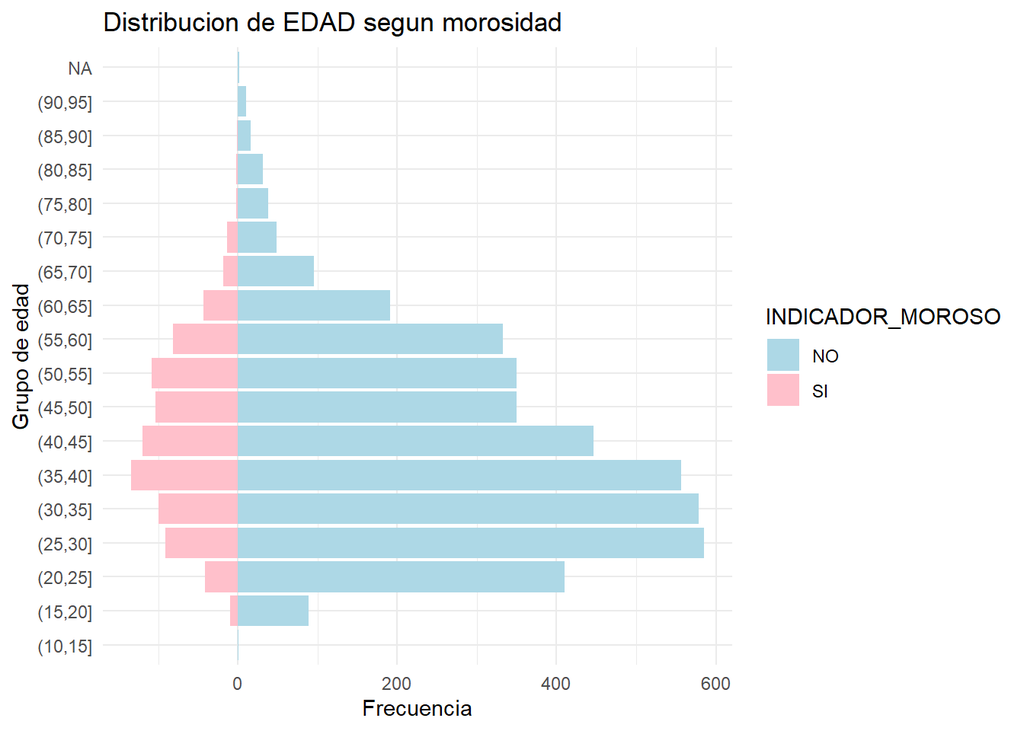

```r
# Edad
df %>%
  mutate(grupo_edad = cut(EDAD, breaks = seq(0, max(EDAD, na.rm = TRUE), by = 5))) %>%
  group_by(grupo_edad, INDICADOR_MOROSO) %>%
  summarise(n = n(), .groups = "drop") %>%
  mutate(n = ifelse(INDICADOR_MOROSO == "SI", -n, n)) %>%
  ggplot(aes(x = grupo_edad, y = n, fill = INDICADOR_MOROSO)) +
    geom_col() +
    coord_flip() +
    scale_fill_manual(values = c("SI" = "pink", "NO" = "lightblue")) +
    labs(title = "Distribucion de EDAD segun morosidad",
         x = "Grupo de edad", y = "Frecuencia") +
    theme_minimal()
```

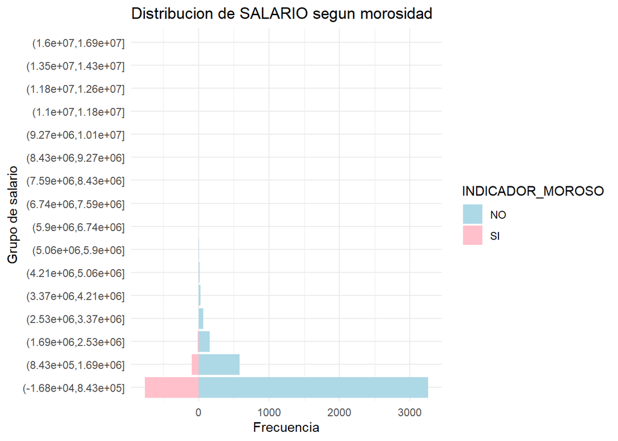

```r
# Salario
df %>%
  mutate(grupo_salario = cut(SALARIO, breaks = 20)) %>%
  group_by(grupo_salario, INDICADOR_MOROSO) %>%
  summarise(n = n(), .groups = "drop") %>%
  mutate(n = ifelse(INDICADOR_MOROSO == "SI", -n, n)) %>%
  ggplot(aes(x = grupo_salario, y = n, fill = INDICADOR_MOROSO)) +
    geom_col() +
    coord_flip() +
    scale_fill_manual(values = c("SI" = "pink", "NO" = "lightblue")) +
    labs(title = "Distribucion de SALARIO segun morosidad",
         x = "Grupo de salario", y = "Frecuencia") +
    theme_minimal()
```

# 10

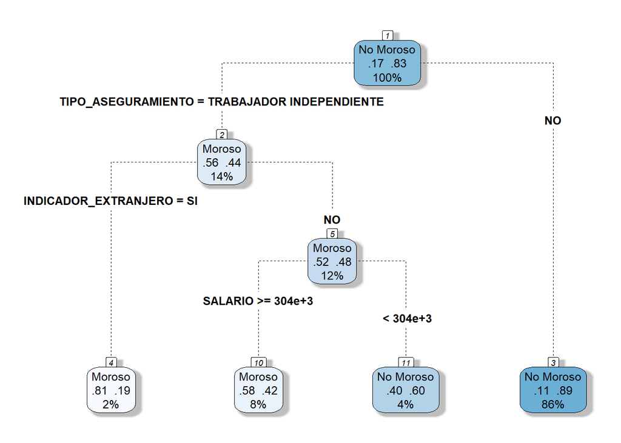

```r
library(rpart)
library(rpart.plot)
# Eliminar indentificacion
df.mod <- df %>%
  select(-IDENTIFICACION)

df.mod <- df.mod %>%
  mutate(
    INDICADOR_MOROSO = factor(INDICADOR_MOROSO,
                              levels = c("SI","NO"),
                              labels = c("Moroso","No Moroso")),
    TIPO_ASEGURAMIENTO = if_else(TIPO_ASEGURAMIENTO == "TRABAJADOR INDEPENDIENTE",
                                 "TRABAJADOR INDEPENDIENTE", "NO")
  )


# Arbol
tree <- rpart(INDICADOR_MOROSO ~ ., data = df.mod, method = "class")

# Graficar arbol
rpart.plot(tree, type = 4, extra = 104, box.palette = "Blues", shadow.col = "gray", nn = TRUE, branch.lty = 2)
```

Este árbol permite dividir la información en agrupaciones representativas, facilitando el análisis enfocado del indicador de morosidad. A través de esta subdivisión, se identifican los grupos con mayor riesgo: los asegurados independientes (comúnmente conocidos como trabajadores autónomos) presentan el perfil más propenso a la morosidad, y dentro de este grupo, el riesgo se incrementa significativamente en personas extranjeras. Para los nacionales, el riesgo también aumenta si el salario supera los ₡300.000. Esta estructura jerárquica de decisiones permite desglosar y distinguir, mediante probabilidad condicional, la probabilidad de morosidad de cada cliente según sus características.

Estas ideas apoyan los resultados dados en el Excel en los pasos anteriores. El hecho de ser extranjeros y ser independientes generalmente corresponde a personas que no tienen ideales de quedarse en el país, sino de llevar lo ganado a su tierra natal, lo que para ellos implica que el aseguramiento sea más un gasto que una inversión, desde su punto de vista.